# DataPraxisAI : Predicting Student Dropout and Academic Success: Methods + Data + Implementation

Capstone(Spring 2026): Week4_and_Week5 Progress Report Assignment

Author

Kareem D. Piper (Advisor: Dr.Shusen Pu)

Published

February 8, 2026

## Project Goal and Research Questions:

- **Project Goal**

  The goal of this capstone project is to test, assess and report the results various multi-class machine learning prediction models on their ability to accuratly predict student dropout in the higher edcation setting. According to Realinho et al. (2022) student attrition and academic failure not only negatively affect the education institutions that students attend, but create greater societal issues. For example, when students dropout prior to completing a degree program it makes them less competitive concerning the job market, which then leads to economic deficiencies, which can lead to inadequate health care access and subsequent more dire socio-economic issues that often disproportionally affect marginalized demographics (Realinho et al., 2022).

  However, according to Mduma (2023), the prediction of student dropout is a particularly challanging issues for education researchers, this is due in large part to class imblance. According to Mduma (2023), many real world datasets concerning studnet dropout are largly skewed towards the reatined or enrolled classes. Many scholars pay particuliar attention to feature enigineering methods when using machine learning methodologies to address the issue of predicting student attrition. However, Mduma (2023) asserted that class imbalance presents limtations concerning model accuracy and generalizabiltiy and thus framed their study aorund that issue. Thus, in this capstone project, I focus on the appropriate data preprocessing methods, feature engineering methods, and methods to adequatly address class imbalnce. Further, I specifically use machine learning models that have a proven track record in the literature (e.g., Realinho et al., 2022; Ridwan et al., 2024) concerning their abiltiy to address multi-class datasets, for example Random Forest(RF), Extreme Gradient Boosting (XGBoost), Light Gradient Boosting Machine (LightGBM) and Catagorical Boosting (CatBoost).

## Research Questions

- **Primary Research Question**

  **RQ1:** Which multi-class machine learning classifier achieves the highest predictive performance as meaured by; accuracy, precesion, and F1-score when applied to the ([UCI Student Dropout Dataset](https://www.kaggle.com/datasets/willatran/original-dataset-for-pss4e6-from-uci-ml-repo/data))?

  To inform the primary research question of this study I asked the following sub-research questions:

  **RQ1a:** How do methods of addressing class imbalance affect the predictive performance of multi-class machine learning classfiers?

  **RQ1b:** How does the performance of gradient boosting models compare to tradtional ensable models in multi-class student attrition prediciton?

## Expanded Methods (updated from week3 paper review):

- *Methods*

  As the main research question of my study centers around comparing multi-class machine learning classifiers and addressing class imblance, to accuratly predict student dropout in a higher education setting. The methods I intend to use correlate directly to those used by (e.g., Mduma, 2023; Realinho et al., 2022). The methods outlined by Realinho et al. (2022), builds on previous work concerning predicitng student dropout by implementing a multi-class approach. While, the methods outlined by Mduma (2023) specifically use five varied data balancing techniques paired with machine learning clssifiers to determine which pairing most accurately predcited student drop out. Thus, the remainder of this methods section is broken down into to parts, 1. Multi-Class Methods and 2. Data Balancing Methods. In the final report for this capstone project, I will provide a detailed account of how these methods are incorparted into my project along with an account of the full machine learnining pipeline methods I use.
- **The Multi-Class Methods**

  The study conducted by Realinho et al. (2022) used data that stemmed from varied sources which were then compiled into one data set. According to Realinho et al. (2022), the sources of data were; 1. the institutions Academic Management System (internal data), 2. the system used for teaching and learning (internal data), 3. annual data from the General Directorate of Higher Education (DGES) for admissions data through the National Competition for Access to Higher Education (CNAES) (external data), and 4. the Contemporary Portugal Database (PORDATA) used for macroeconomic data also (external).The data consited of undergraduate studnets enrolled in seventeen different academic programs for example, journalism, education, nursing, and management. According to Realinho et al. (2022), once all data sources were compiled into the final data set used in the study, it consited of (n = 4,424) cases and (n = 35) features.

  The feautres fell into four main catagories; demographic, socioeconomic, macroeconomic, and academic. The target variable (i.e., dropout, enrolled, or graduating), was multi-class. Concerning data preprocessing, Realinho et al. (2022) used a multi-tool approach. For example, initial data ingestion and preprocessing was done using tools such as Microsoft Access Databases, Microsoft’s Visual Studio Basic, Microsoft Windows suit, and code processing and development was done in Python. According to Realinho et al. (2022), detailed data anlysis was done using tools from the Pandas library, Scikit-learn and Bokeh library for visualizations. The output of descritpive statitics were listed for all features in the form of tables that were parsed based on the major feature catagories. In conducting descriptive statistics and assessing collinarity Realinho et al. (2022) did notice that several features, both within and between feature catagories showed high levels of multicolinarity, which they assed by means of a heat map and Pearson correlation coefficent using 0.7 as a cut point.The Pearson correlation coefficient $r$ measures the strength and direction of the linerar relationship between two features. A cut point $|r| \ge 0.07$ is considered a minimal threshold (see formula below).
  $$r = \frac{\sum_{i=1}^{n} (x_i - \bar{x})(y_i - \bar{y})}
  {\sqrt{\sum_{i=1}^{n} (x_i - \bar{x})^{2}} \, \sqrt{\sum_{i=1}^{n} (y_i - \bar{y})^{2}}}$$

  Where:
  - $r$ = The Pearson correlation coefficent, which measures the strength and direction of the linear relationship between two features
  - $x_i$ = The observed value of the feature $X$ for the $i$-th observation
  - $y_i$ = The observed value of the target $Y$ for the $i$-th observation
  - $\bar{x}$ = The mean of all values of the feature $X$
  - $\bar{y}$ = The mean of all values of the Target $Y$
  - $n$ = The total number of paired observations
  - $\sum_{i=1}^{n}$ = The summation over all observations from $i$ = 1 to $n$
  - $\sqrt{\sum_{i=1}^{n} (x_i - \bar{x})^{2}}$ = the standard deviation for the feature $X$
  - $\sqrt{\sum_{i=1}^{n} (y_i - \bar{y})^{2}}$ = the standard deviation for the target $Y$

  To assess which features would be most important to the model, and to reduce the number of features Realinho et al. (2022) used the Permutation Feature Importance technique. Permutation Feature importance is calculated by oberving differences in model error (i.e., decreases or increases) when feature values are permutated. If premutating feature values causes big differences in the model error, the feature is important to the overal model (see formula below).
  $$PI_j = E_{\text{perm}(j)} - E_{\text{base}}$$

  Where:
  - $PI_j$ = the permutation importnace score for the feaure $_j$
  - $E_{\text{base}}$ = the base model error (i.e., the performance metric) computed on the orginal dataset
  - $E_{\text{perm}(j)}$ = the model error after random permutation of the values of feature $_j$
  - $j$ = the index of the feature being evaluted
  - $E$ = the prediction error metric used for evaluation (e.g., mean squared error, log loss or error rate)

  Concerning the target, Realinho et al. (2022) noted that there was significant class imbalnce, for example, the class label “Graduate” at (n = 2,209) represented 50% of the sample, while “Dropout” (n = 1,421) represented 32%, and “Enrolled” (n = 794) represented 18%. Thus, to assess the error when conducting permutation Realinho et al. (2022), used F1-score as their metric, which they asserted is most adequate when dealing with an imbalanced data set. The F1-score measures the accurcy of classification models assessing how well they predict the positive class by balancing both precision and recall. In the context of selecting “important” features, if permutation causes significant decreases in F1-score, then a feature is deemed important (see formula below).
  $$F_1 = \frac{2PR}{P + R}$$

  Where:
  - $F_1$ = The $F1$-score which is the harmonic mean of precision and recall
  - $P$ = Precision, which is the proportion of predicted postivesthat are true positives
  - $R$ = Recall, which is the ratio of acutal postives that are correctly predicted
  - $2$ = The weighting factor that yeilds the harmoic mean and it penalizes extreme imbalances between $P$ and $R$

  According to Realinho et al. (2022) Permutation Feature Importance was applied to all models suggested by the literature for multi-class prediction, for example Random Forest(RF), Extreme Gradient Boosting (XGBoost), Light Gradient Boosting Machine (LightGBM) and Catagorical Boosting (CatBoost). RF is considred an ensemble learning method that builds upon many decision trees and then aggregates their prediction thus improving model accuracy while reducing overfitting (Ho,1995). XGBoost operates on the premise of gradient boosting and builds trees in a sequential manner where each new tree corrects the errors of the previous tree (Chen & Guestrin, 2016). LightGBM also operates using a gradient boosting method but uses a histogram-based tree framework while it learns to scale large datasets (Ke et al., 2017). Finally, CatBoost also uses a gradient boosting method but is specfically designed to handle catagorical features (Prokhorenkova et al., 2018). See below for the formulas of all multi-class classifiers used by Realinho et al. (2022) in their study.
- **Random Forest Formula**
  $$\hat{y} = \frac{1}{B}\sum_{b=1}^{B} T_b(x)$$

  Where:
  - $\hat{y}$ = The final predicted out of the RF model
  - $B$ = The total number of decision trees in the RF
  - $T_b(x)$ = The prediction of $b$-th decision tree for input $x$
  - $x$ = The feauture vector (i.e., the feature observation)
  - $\sum_{b=1}^{B}$ = The aggregation accross all trees
- **Extreme Gradient Boosting Formula**
  $$\hat{y}_i = \sum_{k=1}^{K} f_k(x_i),
  \quad f_k \in \mathcal{F}$$

  Where:
  - $\hat{y}_i$ = The pridcited output for the observation $i$
  - $K$ = The number of trees (i.e., the number of boosting interations)
  - $f_k(x_i)$ = The prediction from the $k-th$ decision tree
  - $x_i$ = The feature vector for the obeservation $i$
  - $F$ = The space of all possible decision trees
- **Light Gradient Boosting Machine Formula**
  $$\hat{y}_i^{(t)} = \hat{y}_i^{(t-1)} + \eta f_t(x_i)$$

  Where:
  - $\hat{y}_i^{(t)}$ = The updated observation $i$ at interation $t$
  - $\hat{y}_i^{(t-1)}$ = The prediction from the previous boosting intertation
  - $\eta$ = The learning rate while controlng for the contribution of each new tree
  - $f_t(x_i)$ = The prediction of the tree added at interation $t$
  - $x_i$ = The feature vector for observation $i$
- **Catagorical Boosting Formula**
  $$\hat{y}_i = \sum_{t=1}^{T} \eta f_t(x_i)$$

  Where:
  - $\hat{y}_i$ = The predicted output for observation $i$
  - $T$ = The total number of trees (i.e., boosting interations)
  - $\eta$ = The learning rate
  - $f_t(x_i)$ = The predcition from the tree at interation $t$
  - $x_i$ = The input vector including the catgorical variables

  The methods used by Realinho et al. (2022) more than adequatly address their research question. Starting with the data ingestion process, by compiling a data set from both sources native to the universty and external, they assured that features in the data set would afford them the oppurtunity to gain both a macro and micro perspective conerning the phenomena of student dropout and acadmic success. Further, in dealing with class imbalance, by utalizing Permutation Feature Importance, Realinho et al. (2022) assured that only features that contributed to the postive predciton of the class would be included in their model thus improving model fit and accuracy. Finally by incorparting various multi-class calssifieres into their pipeline, Realinho et al. (2022) assured that they would be able to conduct model comparison and select the best model for their data set.
- **Data Balancing Methods**

  Mduma (2023) used two publicly available datasets from developing countries to test their methods. The first data set stemmed from Uwezo an non-governmental organization (NGO) in Tazania, and the second dataset was dervied from india. The Uwezo dataset consisted information on student learning at the country level gathered from thousands of households Mduma (2023). The Uwezo data set consited on (n = 61,340) cases, and concering the classes 98.4% were in the retained class and 1.6% were in the dropout class. The dataset from India concsited of (n = 11, 257) cases of which 95.1% were in the retained class, and 4.9% were in the dropout class (Mduma, 2023). Both datasets consited of features that spannded demograhics, academics and socioeconomic catagories. Mduma (2023), asserted that they conducted pre-processing of both sets, specifically, they cleaned the sets for missing values by implementing median and zero imputting where necessary.

  According to Mduma (2023), five data balancing techniques were used on the datasets to address the class imbalance; 1. Random Under Sampling (RUS), 2. Random Over Sampling (ROS), 3. Synthetic Minority Over Sampling (SMOTE), 4. Synthetic Minority Over Sampling with Edited Nearest Neighbors (SMOTE ENN), and 5. Sythentc Minority Over Sampling with TOMEK Links (SMOTE TOMEK). Concerning RUS, this technique works by randomly removing observations from the majority class until the classes are approximatley equal. ROS, is the oposite of RUS, and works by randomly duplicating the minority class until the classes are approximatly equaly. SMOTE works by generating a new synthetic minority class, which is done by interporlating the minority class using the nearest neighbor until both the minority and majority class match. SMOTE ENN works the same as SMOTE but adds a cleaning step that removes missclassfied classes due to the nearest neighbor step, this reduces statistical noise and overlap. Finally, SMOTE TOMEK also works the same as SMOTE but uses TOMEK links, which remove pairs of nearest neighbors instances from the majority class that are in close proximity to eachother. The decision boundry is cleaned thus reducing statistical noise and improving model performance Mduma (2023). The formulas for all class balancing techniques incorparted by Mduma (2023) are below.
- **Random Under Sampling Formula**
  $$\alpha_{us} = \frac{N_{m}}{N_{rM}}$$

  Where:
  - $\alpha_{us}$ = The under sampling ratio
  - $N_m$ = The number of class samples in the minority
  - $N_{rM}$ = The number of majority class samples after under sampling
- **Random Over Sampling Formula**
  $$\alpha_{os} = \frac{N_{r m}}{N_{m}}$$

  Where:
  - $\alpha_{os}$ = Is the oversampling ration
  - $N_m$ = The orginal number of the minority class samples
  - $N_{rM}$ = The number of samples in the minority class after over-sampling
- **Synthetic Minority Oversampling Formula**
  $$x_{\text{new}} = x_i + \lambda \left(x_{nn} - x_i\right)$$

  Where:
  - $x_{new}$ = The newly generated synthtic minority class sample
  - $x_i$ = The original minority class instance
  - $x_{nn}$ = Is on of the $k$-nearest neighbors of $x_i$
  - $\lambda$ = Is the random interporlation where 0 $\le$ $\lambda$ $\le$ 1
  - $k$ = The total number of nearest neighbors considered
- **Synthetic Minority Oversampling with Edited Nearest Neighbors Formula**
  $$D^{*} = \text{ENN}\bigl(\text{SMOTE}(D)\bigr)$$

  Where:
  - $D$ = The original imbalanced dataset
  - $SMOTE(D)$ = The dataset after synthetic minority over samples are generated
  - $ENN(.)$ = The rule that edits the nearest neighbors that may be missclassfied or ambigious
  - $D^{*}$ = The final cleaned and balanced dataset
- **Synthetic Minority Oversampling with TOMEK Links Formula**
  $$D^{*} = D_{\text{SMOTE}} \setminus TL$$

  Where:
  - $D_SMOTE$ = The dataset after minority synthetic over sampling
  - $TL$ = The TOMEK link sets between the minority and majority classes
  - $\backslash$ = The removal operator (i.e.,set subtraction)
  - $D^{*}$ = The final balanced dataset after overlapping TOMEK links are removed

  In addtion to the five data blancing techniques mentioned above, Mduma (2023), asserted that they also used three seperate classification models (i,e, LR, RF, and MLP) to assess which when paired with a datablancing technique would yeild the most optimal results. Using an experimental methodlogy, the three models were compared and assesed for accuracy in six intances; 1. On the orginal unbalanced dataset, 2. on the ROS balanced dataset, 3. RUS balanced dataset, 4. SMOTE balanced dataset, 5. SMOTE ENN balanced dataset, and 6. SMOTE TOMEK balanced dataset. Concerning model evaluation specifically for measures of accuracy, Mduma (2023), asserted that they chose 1. Geometric Mean ($G_m$), F-measure ($F_m$), and Adjacent Geometric Mean ($AG_m$). According to Mduma (2023), these measures of model accuracy were choosen as they are particularly robust against unbalanced datasets. The ($G_m$) works by measuring the balance between sensitivity and specificity and rewards models that perfrom well on both minority and majority classes. The ($F_m$) measures the harmonic mean of precision and recall and rewards models that show a balanced perfromance on the positive class. The ($AG_m$) is an extention of the ($G_m$) and works by adotping class imbalance calculations penalizing poor minority class performance Mduma (2023). Finally, accroding to Mduma (2023), both datasets were split into training, validation and testing sets at 60%, 20% and 20% respectively. For all model formulas and measures of accuracy formulas used by Mduma (2023) in their study see below.
- **Logistic Regression Formula**
  $$P(y=1 \mid x) = \sigma(w^T x + b)$$

  Where The Sigmoid (i.e., the activation function) is:
  $$\sigma(z) = \frac{1}{1 + e^{-z}}$$

  Where:
  - $P(y = 1 | x)$ = The probality of a class 1 given the input vector $x$
  - $\sigma(.)$ = The sigmiod or the logestic function
  - $w$ = The weight vector
  - ${w^T x}$ = The dot product between the weights and the features
  - $x$ = The input fature vector
  - $b$ = The bias or intercept term
  - $z$ = Is the ${w^T x}$ + $b$ which = the linear predictor
  - $e$ = Euler’s number which is the base of the logarithim
- **Multilayer Perceptron Formula**
  $$a^{(l)} = \sigma\left(W^{(l)} a^{(l-1)} + b^{(l)}\right)$$

  Where:
  - $a^{(l)}$ = The activation vector or output of layer $l$
  - $W^{(l)}$ = The weight matrix for layer $l$ which maps inputs from preious layers
  - $a^{(l-1)}$ = The acti activation layer from the previous vector ($l$ - 1)
  - $b^{(l)}$ = The bias vector of layer $l$
  - $(.) = The activation function applied element wise (e.g., sigmoid, ReLU or tanh)
  - $l$ = The index representing the current layer in the network
- **Geometric Mean Formula**
  $$G_m = \sqrt{\text{TPR} \times \text{TNR}}$$

  Where:
  - $G_m$ = The geometric mean score
  - $TPR$ = The true positive rate of (i.e.,sensitivity or recall)
  - $TNR$ = The true negative rate (i.e, specificity)

  And:
  $$\text{TPR} = \frac{TP}{TP + FN}$$
  $$\text{TNR} = \frac{TN}{TN + FP}$$

  Where:
  - $TP$ = True Positive
  - $TN$ = True Negative
  - $FP$ = False Positive
  - $FN$ = False Negative
- **F-Measure Formula**
  $$F_m = \frac{2PR}{P + R}$$

  Where:
  - $F_m$ = The F-measure or the F1-Score
  - $P$ = Precision
  - $R$ = Recall

  And:
  $$P = \frac{TP}{TP + FP}$$
  $$R = \frac{TP}{TP + FN}$$

  Where:
  - $TP$ = True Positive
  - $FN$ = False Negative
  - $FP$ = False Positive
- **Adjusted Geometric Mean Formula**
  $$AG_m = \sqrt{\text{TPR} \times \text{TNR} \times (1 - IR)}$$

  Where:
  - $AG_m$ = The adjusted geometric mean
  - $TPR$ = The true positive rate (i.e., recall)
  - $TNR$ = The true negative rate (i.e., specificity)
  - $IR$ = The imbalance ratio

  And:
  $$IR = \frac{N_{\text{min}}}{N_{\text{maj}}}$$

  Where:
  - $IR$ = The imbalanced ratio
  - $N_{min}$ = The number of samples in the minority class
  - $N_{maj}$ = The number of samples in the majority class

## Dataset and Access

- *Dataset Characteristics*

  As mentioned previously the dataset I am using stems from the UC Irvine Machine Learning Repository and it is called “Predecting Students’ Dropout and Academic Success”(Realinho et al., 2021). Realinho et al. (2021) characterize the dataset as tubular, and state that it is meant for the social sciences, spefically for researchers working on classification based projects. There are (n = 4,424) cases and (n = 36) features in the dataset. The feature types according to Realinho et al. (2021) consist of real, catagorical and integers based feautres. According to Realinho et al. (2021) the dataset was created specifically to help researchers interested in studying the factors that contribute to student dropout or academic failure in higher education using machine learning methods. There target has three catagories (i.e., dropout, enrolled and graduate). According to Realinho et al. (2021) the dataset was rigorously preprocessed and consist of no null or missing values.
- *Dataset Access*

  The dataset can be accessed here : ([UCI Student Dropout Dataset](https://www.kaggle.com/datasets/willatran/original-dataset-for-pss4e6-from-uci-ml-repo/data))

## Implementation and Experiments

- **Exploratory Data Analysis**

  Below I perform some exploritory data analysis (EDA) on the UCI Student Drop Out Dataset. My goal is to gain a deeper understanding of the datasets’ features, their realtionship to eachother and the target classes. EDA is a fundamental step in the machine learning pipeline as data may present limitaitons concerning the chosen methods.

```python
import os
from pathlib import Path

import numpy as np
import pandas as pd
import matplotlib.pyplot as plt
import matplotlib.ticker as ticker
from matplotlib.ticker import MaxNLocator
import seaborn as sns
from math import ceil

from sklearn.feature_selection import mutual_info_classif
from sklearn.model_selection import StratifiedKFold, cross_val_score
from sklearn.impute import SimpleImputer
from sklearn.preprocessing import LabelEncoder
from sklearn.linear_model import LogisticRegression
from sklearn.metrics import accuracy_score, make_scorer

from sklearn.ensemble import RandomForestClassifier, GradientBoostingClassifier
from xgboost import XGBClassifier
from lightgbm import LGBMClassifier
from catboost import CatBoostClassifier
```

```python
import os
from pathlib import Path
import pandas as pd

# Start from the directory containing the current QMD
qmd_path = os.environ.get("QUARTO_DOCUMENT_PATH")
start_dir = Path(qmd_path).resolve().parent if qmd_path else Path.cwd()

# Walk upwards until we find a 'data' directory
repo_root = None
for p in [start_dir] + list(start_dir.parents):
    if (p / "data").is_dir():
        repo_root = p
        break

if repo_root is None:
    raise FileNotFoundError(
        f"Could not find a 'data/' folder by searching upward from: {start_dir}"
    )

data_dir = repo_root / "data"
train_path = data_dir / "train.csv"
test_path  = data_dir / "test.csv"

print("Start dir:", start_dir)
print("Repo root:", repo_root)
print("Train exists:", train_path.exists(), train_path)
print("Test exists:", test_path.exists(), test_path)

train_data = pd.read_csv(train_path)
test_data  = pd.read_csv(test_path)

print("Train shape:", train_data.shape)
print("Test shape:", test_data.shape)
```

```
Start dir: /Users/kareempiper/Projects/IDC6940_DataPraxisAI/hw
Repo root: /Users/kareempiper/Projects/IDC6940_DataPraxisAI
Train exists: True /Users/kareempiper/Projects/IDC6940_DataPraxisAI/data/train.csv
Test exists: True /Users/kareempiper/Projects/IDC6940_DataPraxisAI/data/test.csv
Train shape: (3539, 37)
Test shape: (885, 37)
```

```python
# Show all columns
pd.set_option('display.max_columns', None)
train_data.head()
```

|  | Marital status | Application mode | Application order | Course | Daytime/evening attendance | Previous qualification | Previous qualification (grade) | Nacionality | Mother's qualification | Father's qualification | Mother's occupation | Father's occupation | Admission grade | Displaced | Educational special needs | Debtor | Tuition fees up to date | Gender | Scholarship holder | Age at enrollment | International | Curricular units 1st sem (credited) | Curricular units 1st sem (enrolled) | Curricular units 1st sem (evaluations) | Curricular units 1st sem (approved) | Curricular units 1st sem (grade) | Curricular units 1st sem (without evaluations) | Curricular units 2nd sem (credited) | Curricular units 2nd sem (enrolled) | … |
| --- | --- | --- | --- | --- | --- | --- | --- | --- | --- | --- | --- | --- | --- | --- | --- | --- | --- | --- | --- | --- | --- | --- | --- | --- | --- | --- | --- | --- | --- | --- |
| 0 | 1 | 43 | 1 | 9238 | 1 | 39 | 120.0 | 1 | 2 | 1 | 1 | 2 | 118.6 | 0 | 0 | 0 | 1 | 1 | 0 | 21 | 0 | 9 | 11 | 14 | 10 | 12.400000 | 0 | 6 | 10 | … |
| 1 | 1 | 39 | 1 | 9130 | 1 | 1 | 133.1 | 1 | 1 | 1 | 90 | 1 | 120.0 | 1 | 0 | 1 | 0 | 1 | 0 | 41 | 0 | 0 | 5 | 5 | 0 | 0.000000 | 1 | 0 | 5 | … |
| 2 | 1 | 44 | 1 | 9003 | 1 | 39 | 140.0 | 1 | 1 | 38 | 9 | 6 | 140.0 | 0 | 0 | 0 | 1 | 1 | 0 | 21 | 0 | 0 | 6 | 13 | 4 | 11.750000 | 0 | 0 | 6 | … |
| 3 | 1 | 16 | 1 | 9070 | 1 | 1 | 125.0 | 1 | 1 | 1 | 4 | 4 | 120.8 | 1 | 0 | 0 | 1 | 0 | 0 | 18 | 0 | 0 | 6 | 6 | 6 | 14.500000 | 0 | 0 | 6 | … |
| 4 | 1 | 17 | 1 | 9500 | 1 | 1 | 142.0 | 1 | 37 | 37 | 5 | 5 | 131.3 | 1 | 0 | 0 | 1 | 0 | 0 | 19 | 0 | 0 | 8 | 8 | 7 | 14.731429 | 0 | 0 | 8 | … |

```python
train_data.describe()
```

|  | Marital status | Application mode | Application order | Course | Daytime/evening attendance | Previous qualification | Previous qualification (grade) | Nacionality | Mother's qualification | Father's qualification | Mother's occupation | Father's occupation | Admission grade | Displaced | Educational special needs | Debtor | Tuition fees up to date | Gender | Scholarship holder | Age at enrollment | International | Curricular units 1st sem (credited) | Curricular units 1st sem (enrolled) | Curricular units 1st sem (evaluations) | Curricular units 1st sem (approved) | Curricular units 1st sem (grade) | Curricular units 1st sem (without evaluations) | Curricular units 2nd sem (credited) | Curricular units 2nd sem (enrolled) | … |
| --- | --- | --- | --- | --- | --- | --- | --- | --- | --- | --- | --- | --- | --- | --- | --- | --- | --- | --- | --- | --- | --- | --- | --- | --- | --- | --- | --- | --- | --- | --- |
| count | 3539.000000 | 3539.000000 | 3539.000000 | 3539.000000 | 3539.000000 | 3539.000000 | 3539.000000 | 3539.000000 | 3539.000000 | 3539.000000 | 3539.000000 | 3539.000000 | 3539.000000 | 3539.000000 | 3539.000000 | 3539.000000 | 3539.000000 | 3539.000000 | 3539.000000 | 3539.000000 | 3539.000000 | 3539.000000 | 3539.000000 | 3539.000000 | 3539.000000 | 3539.000000 | 3539.000000 | 3539.000000 | 3539.000000 | … |
| mean | 1.174343 | 18.660921 | 1.727042 | 8850.986719 | 0.892060 | 4.708675 | 132.684713 | 1.840068 | 19.461147 | 22.291325 | 10.815767 | 10.974569 | 126.876745 | 0.548743 | 0.011585 | 0.109918 | 0.881605 | 0.350664 | 0.252614 | 23.249506 | 0.024301 | 0.717152 | 6.265329 | 8.291325 | 4.701611 | 10.622981 | 0.139870 | 0.545352 | 6.226900 | … |
| std | 0.597108 | 17.487095 | 1.307274 | 2081.250633 | 0.310349 | 10.436904 | 13.202248 | 6.862320 | 15.565408 | 15.323980 | 26.089260 | 25.267655 | 14.530706 | 0.497689 | 0.107024 | 0.312832 | 0.323121 | 0.477245 | 0.434573 | 7.605164 | 0.154003 | 2.379597 | 2.494418 | 4.187610 | 3.095471 | 4.871221 | 0.663121 | 1.923602 | 2.219626 | … |
| min | 1.000000 | 1.000000 | 0.000000 | 33.000000 | 0.000000 | 1.000000 | 95.000000 | 1.000000 | 1.000000 | 1.000000 | 0.000000 | 0.000000 | 95.000000 | 0.000000 | 0.000000 | 0.000000 | 0.000000 | 0.000000 | 0.000000 | 17.000000 | 0.000000 | 0.000000 | 0.000000 | 0.000000 | 0.000000 | 0.000000 | 0.000000 | 0.000000 | 0.000000 | … |
| 25% | 1.000000 | 1.000000 | 1.000000 | 9085.000000 | 1.000000 | 1.000000 | 125.000000 | 1.000000 | 2.000000 | 3.000000 | 4.000000 | 4.000000 | 117.800000 | 0.000000 | 0.000000 | 0.000000 | 1.000000 | 0.000000 | 0.000000 | 19.000000 | 0.000000 | 0.000000 | 5.000000 | 6.000000 | 3.000000 | 11.000000 | 0.000000 | 0.000000 | 5.000000 | … |
| 50% | 1.000000 | 17.000000 | 1.000000 | 9238.000000 | 1.000000 | 1.000000 | 133.100000 | 1.000000 | 19.000000 | 19.000000 | 5.000000 | 7.000000 | 126.000000 | 1.000000 | 0.000000 | 0.000000 | 1.000000 | 0.000000 | 0.000000 | 20.000000 | 0.000000 | 0.000000 | 6.000000 | 8.000000 | 5.000000 | 12.320000 | 0.000000 | 0.000000 | 6.000000 | … |
| 75% | 1.000000 | 39.000000 | 2.000000 | 9556.000000 | 1.000000 | 1.000000 | 140.000000 | 1.000000 | 37.000000 | 37.000000 | 9.000000 | 9.000000 | 134.900000 | 1.000000 | 0.000000 | 0.000000 | 1.000000 | 1.000000 | 1.000000 | 25.000000 | 0.000000 | 0.000000 | 7.000000 | 10.000000 | 6.000000 | 13.399000 | 0.000000 | 0.000000 | 7.000000 | … |
| max | 6.000000 | 57.000000 | 9.000000 | 9991.000000 | 1.000000 | 43.000000 | 190.000000 | 108.000000 | 44.000000 | 44.000000 | 194.000000 | 195.000000 | 190.000000 | 1.000000 | 1.000000 | 1.000000 | 1.000000 | 1.000000 | 1.000000 | 70.000000 | 1.000000 | 20.000000 | 26.000000 | 45.000000 | 26.000000 | 18.875000 | 12.000000 | 19.000000 | 23.000000 | … |

```python
train_data.info()
```

```
<class 'pandas.DataFrame'>
RangeIndex: 3539 entries, 0 to 3538
Data columns (total 37 columns):
 #   Column                                          Non-Null Count  Dtype
---  ------                                          --------------  -----
 0   Marital status                                  3539 non-null   int64
 1   Application mode                                3539 non-null   int64
 2   Application order                               3539 non-null   int64
 3   Course                                          3539 non-null   int64
 4   Daytime/evening attendance                      3539 non-null   int64
 5   Previous qualification                          3539 non-null   int64
 6   Previous qualification (grade)                  3539 non-null   float64
 7   Nacionality                                     3539 non-null   int64
 8   Mother's qualification                          3539 non-null   int64
 9   Father's qualification                          3539 non-null   int64
```

[output cut: 29 more lines]

```python
test_data.info()
```

```
<class 'pandas.DataFrame'>
RangeIndex: 885 entries, 0 to 884
Data columns (total 37 columns):
 #   Column                                          Non-Null Count  Dtype
---  ------                                          --------------  -----
 0   Marital status                                  885 non-null    int64
 1   Application mode                                885 non-null    int64
 2   Application order                               885 non-null    int64
 3   Course                                          885 non-null    int64
 4   Daytime/evening attendance                      885 non-null    int64
 5   Previous qualification                          885 non-null    int64
 6   Previous qualification (grade)                  885 non-null    float64
 7   Nacionality                                     885 non-null    int64
 8   Mother's qualification                          885 non-null    int64
 9   Father's qualification                          885 non-null    int64
```

[output cut: 29 more lines]

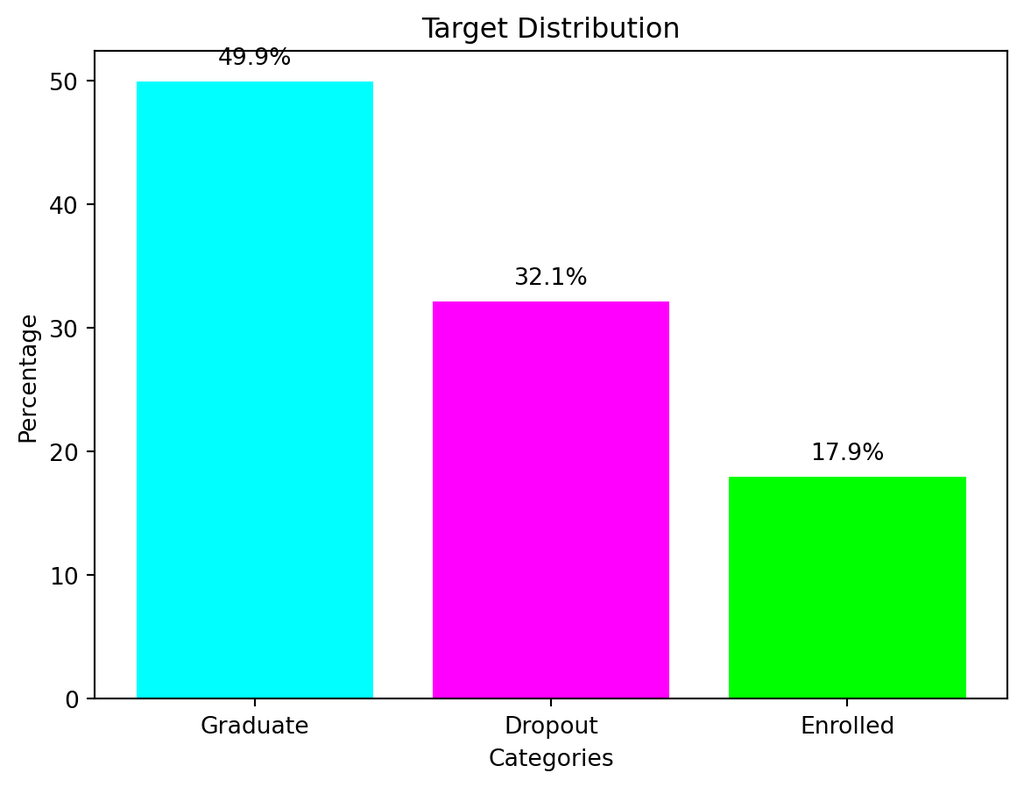

```python
tg_cnts = train_data.Target.value_counts()
tg_cnts_sum = tg_cnts.sum()
tg_cnts_pct = (tg_cnts / tg_cnts_sum) * 100

# Plot
colors = ['#00FFFF', '#FF00FF', '#00FF00']  # Neon blue, magenta, lime green

plt.bar(tg_cnts.index, tg_cnts_pct, color=colors)
plt.xlabel('Categories')
plt.ylabel('Percentage')
plt.title('Target Distribution')

# Percentages on bars
for i, pct in enumerate(tg_cnts_pct):
    plt.text(i, pct + 1, f'{pct:.1f}%', ha='center', va='bottom')

plt.show()
```

```python
# Feature Cardinality Check
feature_count = (
    train_data.drop(columns=['Target'])
    .nunique()
    .reset_index()
    .rename(columns={'index': 'feature', 0: 'unique_count'})
    .sort_values(by='unique_count')
)

feature_count
```

|  | feature | unique_count |
| --- | --- | --- |
| 4 | Daytime/evening attendance | 2 |
| 13 | Displaced | 2 |
| 15 | Debtor | 2 |
| 14 | Educational special needs | 2 |
| 20 | International | 2 |
| 18 | Scholarship holder | 2 |
| 17 | Gender | 2 |
| 16 | Tuition fees up to date | 2 |
| 0 | Marital status | 6 |
| 2 | Application order | 8 |
| 34 | Inflation rate | 9 |
| 32 | Curricular units 2nd sem (without evaluations) | 10 |
| 35 | GDP | 10 |
| 33 | Unemployment rate | 10 |
| 26 | Curricular units 1st sem (without evaluations) | 11 |
| 5 | Previous qualification | 17 |
| 3 | Course | 17 |
| 1 | Application mode | 18 |
| 27 | Curricular units 2nd sem (credited) | 19 |
| 7 | Nacionality | 19 |
| 30 | Curricular units 2nd sem (approved) | 20 |
| 21 | Curricular units 1st sem (credited) | 21 |
| 28 | Curricular units 2nd sem (enrolled) | 22 |
| 24 | Curricular units 1st sem (approved) | 23 |
| 22 | Curricular units 1st sem (enrolled) | 23 |
| 8 | Mother's qualification | 28 |
| 29 | Curricular units 2nd sem (evaluations) | 30 |
| 10 | Mother's occupation | 31 |
| 9 | Father's qualification | 32 |
| 23 | Curricular units 1st sem (evaluations) | 35 |
| 11 | Father's occupation | 41 |
| 19 | Age at enrollment | 46 |
| 6 | Previous qualification (grade) | 99 |
| 12 | Admission grade | 591 |
| 31 | Curricular units 2nd sem (grade) | 674 |
| 25 | Curricular units 1st sem (grade) | 683 |

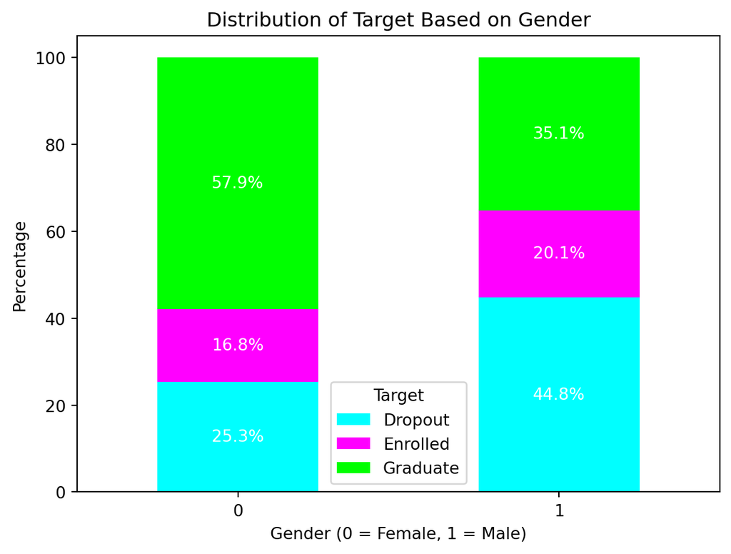

```python
# Target Distribution by Gender
crosstab_gender = pd.crosstab(train_data['Gender'], train_data['Target'])
crosstab_gender = crosstab_gender.div(crosstab_gender.sum(axis=1), axis=0) * 100

# Plot
colors = ['#00FFFF', '#FF00FF', '#00FF00']  # Neon blue, magenta, lime green
ax_gender = crosstab_gender.plot(kind='bar', stacked=True, color=colors)
plt.xlabel('Gender (0 = Female, 1 = Male)')
plt.ylabel('Percentage')
plt.title('Distribution of Target Based on Gender')
plt.legend(title='Target')
plt.xticks(rotation=0)

for p in ax_gender.patches:
    width = p.get_width()
    height = p.get_height()
    x, y = p.get_xy()
    ax_gender.annotate(
        f'{height:.1f}%',
        (x + width / 2, y + height / 2),
        ha='center',
        va='center',
        fontsize=10,
        color='white'
    )

plt.show()
```

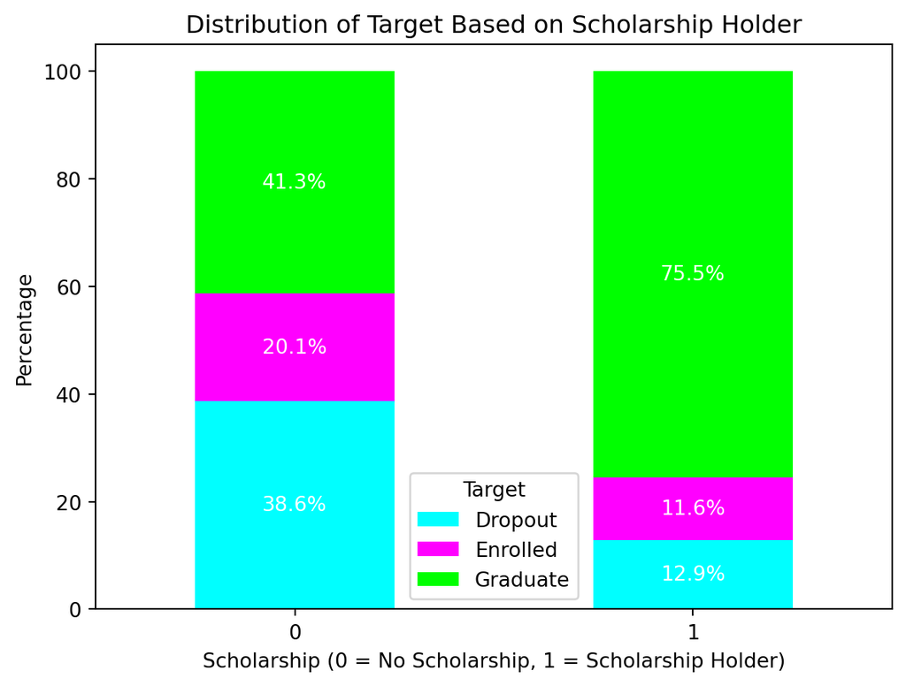

```python
# Create a crosstab to count the occurrences of each Target value for each Scholarship status
crosstab_ss = pd.crosstab(train_data['Scholarship holder'], train_data['Target'])

# Normalize the crosstab counts to percentages
crosstab_ss = crosstab_ss.div(crosstab_ss.sum(axis=1), axis=0) * 100

# Plot the data
colors = ['#00FFFF', '#FF00FF', '#00FF00']  # Neon blue, magenta, lime green
ax_ss = crosstab_ss.plot(kind='bar', stacked=True, color=colors)
plt.xlabel('Scholarship (0 = No Scholarship, 1 = Scholarship Holder)')
plt.ylabel('Percentage')
plt.title('Distribution of Target Based on Scholarship Holder')
plt.legend(title='Target')
plt.xticks(rotation=0)

# Annotate the percentage labels on each bar
for p in ax_ss.patches:
    width = p.get_width()
    height = p.get_height()
    x, y = p.get_xy()
    ax_ss.annotate(
        f'{height:.1f}%',
        (x + width / 2, y + height / 2),
        ha='center',
        va='center',
        fontsize=10,
        color='white'
    )

plt.show()
```

[figure not shown]

```python
# Create a crosstab to count the occurrences of each Target value for each Scholarship status
crosstab_ss = pd.crosstab(train_data['Scholarship holder'], train_data['Target'])

# Normalize the crosstab counts to percentages
crosstab_ss = crosstab_ss.div(crosstab_ss.sum(axis=1), axis=0) * 100

# Plot the data
colors = ['#00FFFF', '#FF00FF', '#00FF00']  # Neon blue, magenta, lime green
ax_ss = crosstab_ss.plot(kind='bar', stacked=True, color=colors)
plt.xlabel('Scholarship (0 = No Scholarship, 1 = Scholarship Holder)')
plt.ylabel('Percentage')
plt.title('Distribution of Target Based on Scholarship Holder')
plt.legend(title='Target')
plt.xticks(rotation=0)

# Annotate the percentage labels on each bar
for p in ax_ss.patches:
    width = p.get_width()
    height = p.get_height()
    x, y = p.get_xy()
    ax_ss.annotate(
        f'{height:.1f}%',
        (x + width / 2, y + height / 2),
        ha='center',
        va='center',
        fontsize=10,
        color='white'
    )

plt.show()
```

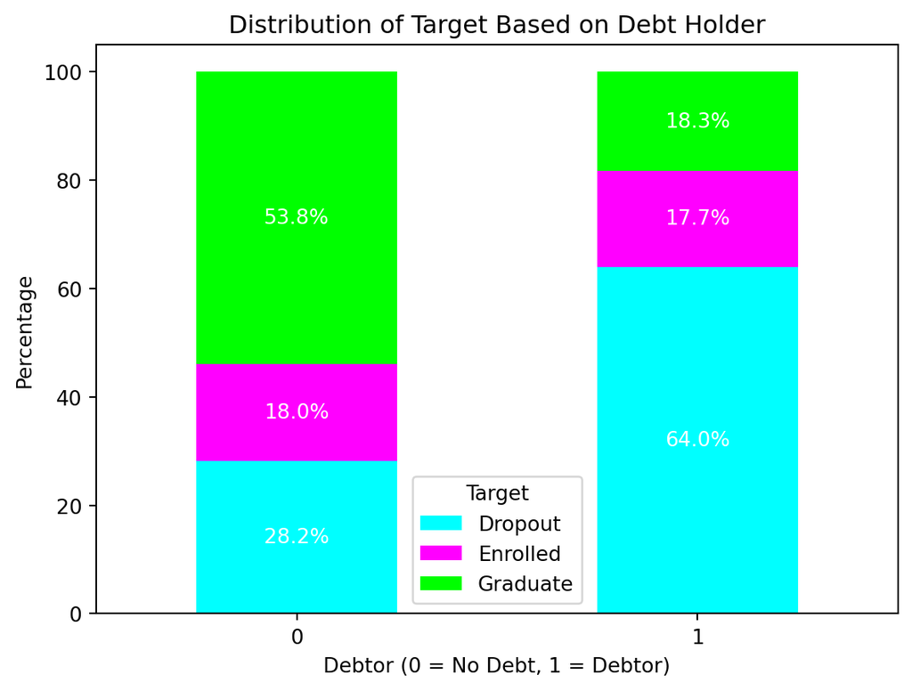

```python
# Create a crosstab to count the occurrences of each Target value for each Debtor status
crosstab_debtor = pd.crosstab(train_data['Debtor'], train_data['Target'])

# Normalize the crosstab counts to percentages
crosstab_debtor = crosstab_debtor.div(crosstab_debtor.sum(axis=1), axis=0) * 100

# Plot the data
colors = ['#00FFFF', '#FF00FF', '#00FF00']  # Neon blue, magenta, lime green
ax_debtor = crosstab_debtor.plot(kind='bar', stacked=True, color=colors)
plt.xlabel('Debtor (0 = No Debt, 1 = Debtor)')
plt.ylabel('Percentage')
plt.title('Distribution of Target Based on Debt Holder')
plt.legend(title='Target')
plt.xticks(rotation=0)

# Annotate the percentage labels on each bar
for p in ax_debtor.patches:
    width = p.get_width()
    height = p.get_height()
    x, y = p.get_xy()
    ax_debtor.annotate(
        f'{height:.1f}%',
        (x + width / 2, y + height / 2),
        ha='center',
        va='center',
        fontsize=10,
        color='white'
    )

plt.show()
```

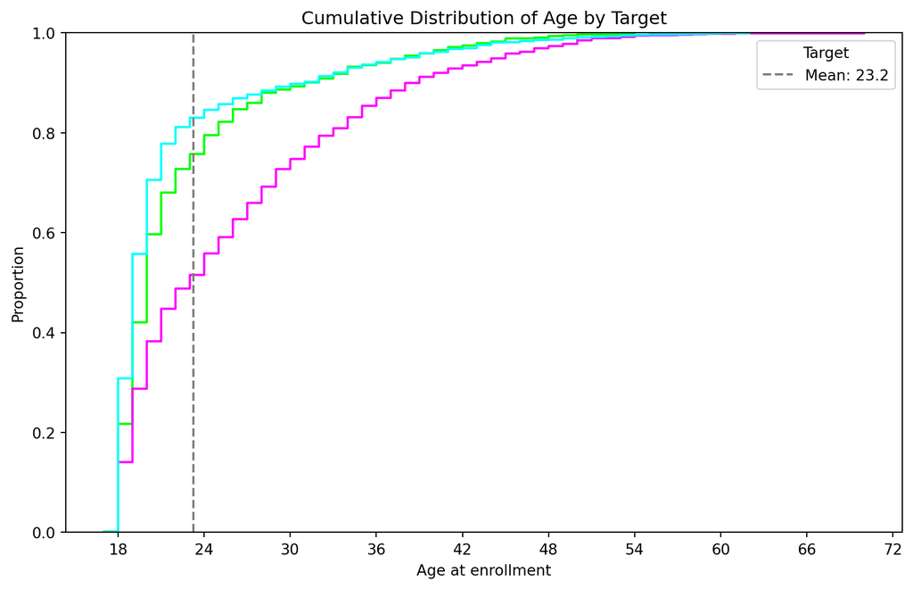

```python
### Age Distribution by Target (ECDF)

plt.figure(figsize=(10, 6))
colors = ['#00FFFF', '#FF00FF', '#00FF00']  # Neon blue, magenta, lime green
plot = sns.ecdfplot(data=train_data, x='Age at enrollment', hue='Target', palette=colors)
plt.xlabel('Age at enrollment')
plt.ylabel('Proportion')
plt.title('Cumulative Distribution of Age by Target')
plot.xaxis.set_major_locator(ticker.MaxNLocator(integer=True))

mean_value = train_data['Age at enrollment'].mean()
plt.axvline(mean_value, color='grey', linestyle='--', label=f'Mean: {mean_value:.1f}')

plt.legend(title='Target')
plt.show()
```

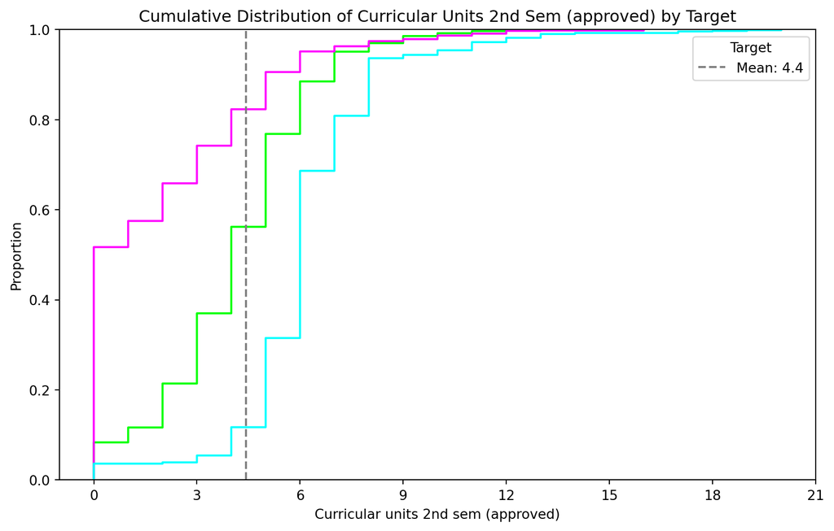

```python
### Approved 2nd Semester Units by Target (ECDF)

plt.figure(figsize=(10, 6))
colors = ['#00FFFF', '#FF00FF', '#00FF00']  # Neon blue, magenta, lime green
plot = sns.ecdfplot(
    data=train_data,
    x='Curricular units 2nd sem (approved)',
    hue='Target',
    palette=colors
)

plt.xlabel('Curricular units 2nd sem (approved)')
plt.ylabel('Proportion')
plt.title('Cumulative Distribution of Curricular Units 2nd Sem (approved) by Target')
plot.xaxis.set_major_locator(ticker.MaxNLocator(integer=True))

mean_value = train_data['Curricular units 2nd sem (approved)'].mean()
plt.axvline(mean_value, color='grey', linestyle='--', label=f'Mean: {mean_value:.1f}')

plt.legend(title='Target')
plt.show()
```

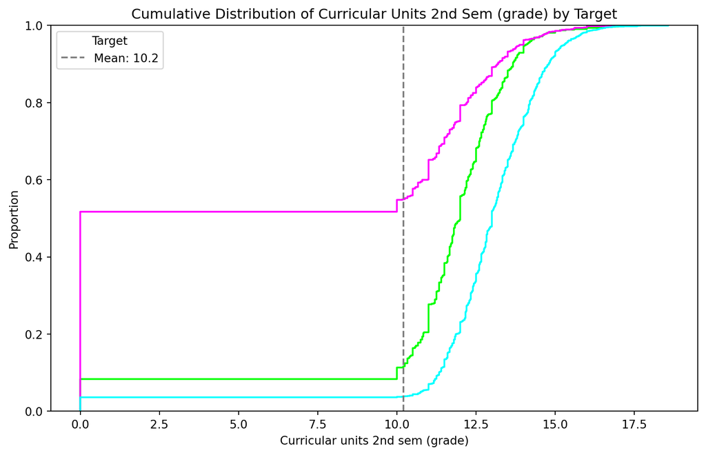

```python
### 2nd Semester Grade Distribution by Target (ECDF)

plt.figure(figsize=(10, 6))
colors = ['#00FFFF', '#FF00FF', '#00FF00']  # Neon blue, magenta, lime green
plot = sns.ecdfplot(
    data=train_data,
    x='Curricular units 2nd sem (grade)',
    hue='Target',
    palette=colors
)

plt.xlabel('Curricular units 2nd sem (grade)')
plt.ylabel('Proportion')
plt.title('Cumulative Distribution of Curricular Units 2nd Sem (grade) by Target')

mean_value = train_data['Curricular units 2nd sem (grade)'].mean()
plt.axvline(mean_value, color='grey', linestyle='--', label=f'Mean: {mean_value:.1f}')

plt.legend(title='Target')
plt.show()
```

```python
### Identification of Categorical Features

# Identify categorical columns based on low cardinality
cat_cols = [
    col for col in train_data.columns
    if col != 'Target' and train_data[col].nunique() <= 8
]

# Convert to categorical dtype (for CatBoost compatibility later)
for col in cat_cols:
    train_data[col] = train_data[col].astype('category')
    test_data[col] = test_data[col].astype('category')

print("Categorical columns:")
print(cat_cols)
```

```
Categorical columns:
['Marital status', 'Application order', 'Daytime/evening attendance', 'Displaced', 'Educational special needs', 'Debtor', 'Tuition fees up to date', 'Gender', 'Scholarship holder', 'International']
```

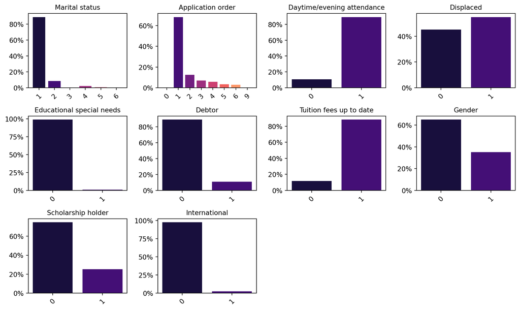

```python
# Categorical feature distributions
n_cols = 4
n_rows = int(np.ceil(len(cat_cols) / n_cols))

fig, axs = plt.subplots(n_rows, n_cols, figsize=(11, 2.2 * n_rows))
axs = np.array(axs).ravel()

# Define a cyberpunk color palette
cyberpunk_palette = sns.color_palette('magma', n_colors=8)

for ax, col in zip(axs, cat_cols):
    vc = train_data[col].value_counts(normalize=True).sort_index()
    # Use the color palette for bars, cycling through it if more categories than colors
    ax.bar(vc.index.astype(str), vc, color=cyberpunk_palette[:len(vc)])
    ax.set_title(col, fontsize=10)
    ax.yaxis.set_major_formatter(plt.FuncFormatter(lambda x, _: f'{x:.0%}'))
    ax.tick_params(axis='x', labelrotation=45)

# Turn off any unused axes
for ax in axs[len(cat_cols):]:
    ax.set_visible(False)
plt.tight_layout()
plt.show()
```

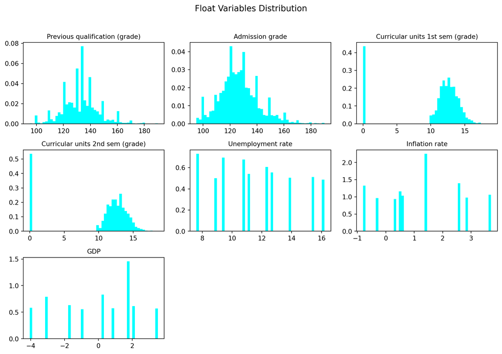

```python
### Continuous Feature Distributions

# Float feature distributions
float_cols = [
    col for col in train_data.columns
    if col != 'Target' and train_data[col].dtype == 'float64'
]

n_cols = 3
n_rows = int(np.ceil(len(float_cols) / n_cols))

fig, axs = plt.subplots(n_rows, n_cols, figsize=(11, 2.5 * n_rows))
axs = np.array(axs).ravel()

for ax, col in zip(axs, float_cols):
    ax.hist(train_data[col], bins=50, density=True, color='#00FFFF') # Neon blue
    ax.set_title(col, fontsize=10)

# Turn off unused axes
for ax in axs[len(float_cols):]:
    ax.axis('off')

plt.suptitle('Float Variables Distribution', fontsize=13, y=1.02)
plt.tight_layout()
plt.show()
```

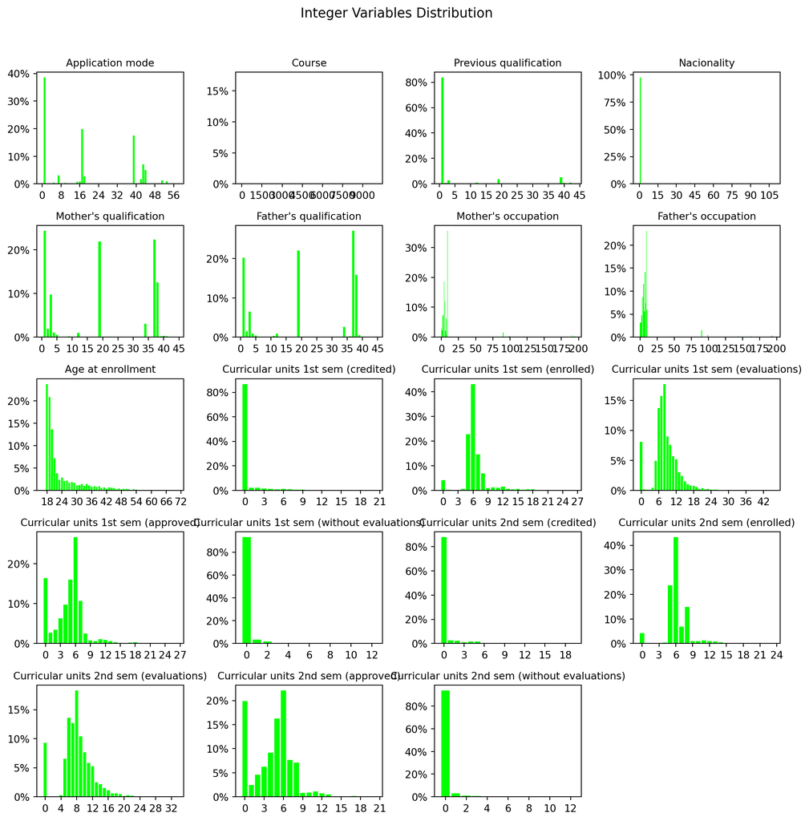

```python
# Integer feature distributions
int_cols = [
    col for col in train_data.columns
    if col != 'Target' and train_data[col].dtype == 'int64'
]

n_cols = 4
n_rows = int(np.ceil(len(int_cols) / n_cols))

fig, axs = plt.subplots(n_rows, n_cols, figsize=(11, 2.2 * n_rows))
axs = np.array(axs).ravel()

for ax, col in zip(axs, int_cols):
    vc = train_data[col].value_counts(normalize=True).sort_index()
    ax.bar(vc.index, vc, color='#00FF00') # Lime green
    ax.xaxis.set_major_locator(MaxNLocator(integer=True))
    ax.yaxis.set_major_formatter(plt.FuncFormatter(lambda x, _: f'{x:.0%}'))
    ax.set_title(col, fontsize=10)

# Turn off unused axes
for ax in axs[len(int_cols):]:
    ax.axis('off')

plt.suptitle('Integer Variables Distribution', fontsize=13, y=1.02)
plt.tight_layout()
plt.show()
```

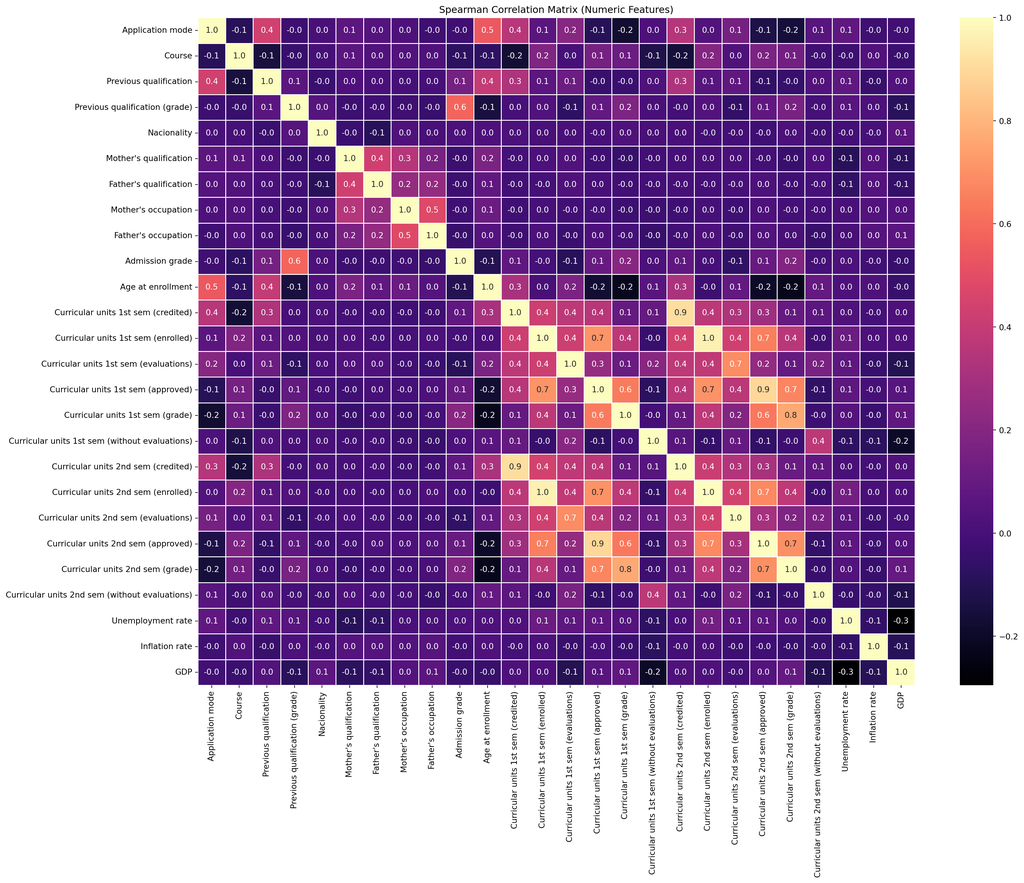

```python
### Spearman Correlation Analysis

# Select numeric features only (exclude Target)
numeric_cols = train_data.select_dtypes(include=['int64', 'float64']).columns
numeric_cols = [col for col in numeric_cols if col != 'Target']

plt.figure(figsize=(20, 15))
sns.heatmap(
    train_data[numeric_cols].corr(method='spearman'),
    cmap='magma',
    annot=True,
    fmt='.1f',
    linewidths=0.5
)
plt.title('Spearman Correlation Matrix (Numeric Features)')
plt.show()
```

## Results

- **Preliminary Results From Exploratory Data Analysis (EDA)**

  The dataset did display significant class imblance with the Graduate class reprsenting 49.9% of the distribution followed by the Dropout Catagory class at 32.1% and finally the Enrolled class at 17.9%. I observed several meaniful relationships accross the feature groups (i.e., demographic, financial and academic). For example, demographic and financial feautres displayed strong correlations to the target. When I ran the crosstab on the gender feature, it showed that males were more likely to dropout and females more likely to graduate. Those students who held scholarships also showed higher graduation rates compared to non-scholarship students, and were less likely to drop out. Further, those students who were in financial distress as indicated by be coded as debtors had lower graduation rates than those coded as non-debters. Concerning academic features, second-semester grades and approved curricular units showed clear dispersion between the target classes, which may indicate importance pertaining to class prediction.

## Issues and Limitations

- **Potential Issues and Limitations Based on EDA**

  As mentioned the dataset does display significant class imblance. This class imbalance if left un-checked can lead to model bias towards the majority class. I also noticed that many of the catagorical features were encoded as intergers which may lead to false interpretation when conducting correlation analysis if not addressed. Another limitation that this data presents is its lack of temporal features. As the data represents a snapshot in time, models may not be able to capture the full complexity of predicting student dropout due to the lack of dynamic changes over time. Finally, as this data stems from a single institution, the findings may present limitation concerning genralizability. Though I am not as concerned with this as the purpose of this study is to test which model and data balancing techniques when paired has the highest accuracy.

## Next Steps

- **Full Machine Learning Pipeline**

  Concerning the next steps in this project, I will be implementing the full machine learning pipeline to test and evaluate multi-class classifiers and class blancing techniqies. I will be conducting all experimentation in google colabs using a jupter notebook. The first step in the pipeline would be to split the dataset into training and testing sets using a 80:20 train_test_split and stratification. All numeric and catagorical features will be preprocessed by imputation and one-hot encoding.

  After the data is preporcessed I will implement the class imbalancing techniques into the pipeline (i.e., RUS, ROS,SMOTE, SMOTE-ENN and SMOTE-Tomek) on the traing set. Once the dataset is blanaced, it will be used to train the multi-class classifiers (i.e., RF, XGBoost, LightGBM, and CatBoost). All models will be evaluted with multi-class metrics however F1-score will be the primary metric. Finally the best model will be evalauted by a confusion matrix and finally permuation feature importance will be used to identify those factors that best predict student dropout and academic success.

## Reference

Aina, C., Baici, E., Casalone, G., & Pastore, F. (2022). The determinants of university dropout: A review of the *socio-economic literature. Socio-Economic Planning Sciences, 79, Article 101102.* https://doi.org/10.1016/j.seps.2021.101102

Andrade-Giron, D., et al.(2023). Predicting student dropout based on machine learning and deep learning: A systematic review. *ICST Transaction on Scalable Information Systems, 10(5),1-11.* https://doi.org/10.4108/eetsis.3586

Bargmann, C., Thiele, L., & Ksuggrld, S. (2022). Motivation matters: Predicting students’ career decidedness and intention to drop out after the first year in higher education. *Higher Education, 83(4), 845-861.* https://doi.org/10.1007/s10734-021-00707-6

Barramuno, M., Meza-Narvaez, C., & Galvez-Garcia, G. (2022). Prediction of student attrition risk using machine learning. *Journal of Applied Research in Higher Education, 14(3), 974-986.* https://doi.org/10.1108/JARHE-02-2021-0073

Chen, T., & Guestrin, C. (2016). XGBoost: A scalable tree boosting system. In Proceedings of the 22nd ACM SIGKDD International Conference on Knowledge Discovery and Data Mining (pp. 785–794). Association for Computing Machinery. https://doi.org/10.1145/2939672.2939785

Delen, D., Davazdahemami, B., & Rasouli Dezfouli, E. (2024). Predicting and mitigating freshman student attrition: A local-explainable machine learning framework. Information Systems Frontiers, 26(2), 641-662. https://doi.org/10.1007/s10796-023-10397-3

Duan, D., Dai, C., & Tu, r. (2021). Research on the predicion of students’ academic performance based on XGBoost. In *Proceedings of the 2021 Tenth International Conference on Educational Innovation through Technology (EITT)* (pp.316-319). IEEE https://doi.org/10.1109/EITT53287.2021.00068

Ho, T. K. (1995). Random decision forests. In Proceedings of the Third International Conference on Document Analysis and Recognition (Vol. 1, pp. 278–282). IEEE. https://doi.org/10.1109/ICDAR.1995.598994

Huo, H. et al. (2023). Predicting dropout for nontraditional undergraduate students: A machine learning approach. *Journal of College Student Retention:Research, Theory & Practice*, 24(4), 1054-1077.https://doi.org/10.1177/1521025120963821

Ke, G., Meng, Q., Finley, T., Wang, T., Chen, W., Ma, W., Ye, Q., & Liu, T.-Y. (2017). LightGBM: A highly efficient gradient boosting decision tree. In I. Guyon et al. (Eds.), *Advances in Neural Information Processing Systems* (Vol. 30, pp. 3147–3155). Curran Associates, Inc. https://proceedings.neurips.cc/paper/2017/hash/6449f44a102fde848669bdd9eb6b76fa-Abstract.html

Kok, C. L., Ho, C.K., Chen, L., Koh, Y. Y., & Tian, B. (2024). A novel predictive modeling for student attrition utilizing machine learning and sustainable big data analytics. *Applied Sciences, 14(21), Article 9633.* https://doi.org/10.3390/app14219633

Mduma, N. (2023). Data balancing techniques for predicting student dropout using machine learning. Data, 8(3), Article 49. https://doi.org/10.3390/data8030049

Mun, J., & Jo, M. (2023). Applying machine learning-based models to prevent university student dropouts. *Journal of Educational Evaluation*, 36(2), 289–313. https://doi.org/10.31158/JEEV.2023.36.2.289

Namoun, A., & Alshanqiti, A. (2020). Predicting student performance using data mining and learning analytics techniques: A systematic literature review. Applied Science, 11(1), Article 237. https://doi.org/10.3390/app11010237

Pek, R.Z., Ozyer, S.T., Elhage, T., Ozyer, T., & Alhajj, R. (2023). The role of machine learning in identifying student at-risk and minimizing failure. *IEEE Access, 11, 1224-1243.* https://doi.org/10.1109/ACCESS.2022.3232984

Parjwal, P., L. R., S., & V., K. (2024). Forcasting student attrition using machine learning. In *Proceedings of the 2024 4th Asian Conference on Innovation in Technology (ASIANCON)* (pp.1-7) IEEE. https://doi.org/10.1109/ASIANCON62057.2024.10838214

Prokhorenkova, L., Gusev, G., Vorobev, A., Dorogush, A. V., & Gulin, A. (2018). CatBoost: Unbiased boosting with categorical features. In *Advances in Neural Information Processing Systems* (Vol. 31, pp. 6638–6648). Curran Associates, Inc. https://proceedings.neurips.cc/paper/2018/hash/14491b756b3a51daac41c24863285549-Abstract.htm

Raschka, S., Liu, Y. (H.), & Mirjalili, V. (2022). Machine learning with PyTorch and scikit-learn: Develop machine learning and deep learning models with Python. Packt Publishing.

Realinho, V., Machado, J., Baptista, L., & Martins, M. V. (2022). Predicting student dropout and academic success. Data, 7(11), Article 146. https://doi.org/10.3390/data7110146

Ridwan, A., Priyatno, A. M., & Ningsih, L. (2024). Predict Students’ Dropout and Academic Success with XGBoost. *Journal of Education and Computer Applications*,*1*(2), 1-8.https://doi.org/10.69693/jeca.v1i2.13

Veliz Palomino, J.C., & Ortega, A. M. (2023). Dropout intentions in higher education: Systematic literature review. *Journal of Efficacy and Responsibility in Education and Science, 16(2), 149-158.* https://doi.org/10.7160/eriesj.2023.160206

Yan, K. (2021). Student performance prediction using XGBoost method from macro perspective. In *Proceedings of the 2021 2nd International Conference on Computing and DataScience(CDS)*(pp.453-459).IEEE.https://doi.org/10.1109/CDS52072.2021.00084